# Module 6 Project

Callback Cats

2022-11-02

# Introduction

The importance of studying wing morphology (whether that be the size, shape, or pigmentation) is that it can aid in the study of taxonomy and evolution across lepidoptera. Past research articles, including Strauss (1990), have shown morphometric variation in forewing and hindwing, specifically in studies on heliconia and ithomiine butterflies. Similar to this research study, we began by digitizing the wings along a metric scale bar. Aerodynamic constraints are one possible reason suggesting greater variability in shape differences from anterior to posterior along the wing. These aerodynamic factors include wing load and muscle development. Another study, Owens et al. (2020), showed that for swallowtails, the forewing shape and size showed stronger phylogenetic signals but evolved more slowly than the respective measures for the hindwing. This study suggested that forewings and hindwings have evolved independently from each other. The different selective pressures may be due to stabilizing selection imposed by dependence on forewings for flight, mimicry, and predation interactions.

We seek to answer three specific questions pertaining to wing-shape evolution across the lepidoptera, an order that includes species from both moths and butterflies. First, do fore- and hindwings vary in their evolutionary rates? Second, does the evolvability of the hind- and forewings vary significantly among major lineages of the lepidoptera? Finally, is there any correlation in forewing and hindwing shape? Our investigation implemented a morphometric approach, in which the wing shape outlines of around 200 Lepidoptera species were characerized.

[figure not shown]

Forewing and Hindwing of Different Lepidoptera, Image from Patil and Magdum (2017)

Great intro. Love the figure!

# Methods

#### Image acquisition

All images of the Lepidoptera were pulled from the Global Biodiversity Information Facility (GBIF), a clearing house of collections and species information. GBIF have created an R package, [rgif](https://www.gbif.org/tool/81747/rgbif), that allows access to GBIF’s application programming interface (API).This packages allows their records to be searchable from the command line.

```r
library(rgbif)
```

#### Digitization

Shape analysis was based on the outline of the hind- and fore-wings of ~200 species of Lepidoptera. The image analysis program FIJI was used to outline the wings. A spline was fit on all hind- and fore-wings.

#### Shape analysis

For the shape analysis, Elliptical Fourier analysis (EFA) was use. EFA collects variables that describes the shapes in the data set as a series of ellipses. Before performing EFA, first the forewing and hindwing were separated in different data sets. Next the issue of arbitrary size differences was addressed by using the Procrustes transformation. Principal Components Analysis (PCA) was then used to distill the EFA data into a set of fewer variables that describe the important variance among the wings. PCA analyzes the digitized files and distills the variables to a set of fewer variables by creating 2 vectors. PC1 is the first vector and accounts for the most variance within the data set. PC2 is the second vector and accounts for the second most variance. The analysis showed a biplot of the first two PCs, the amount of variance explained by each, and a representation of the morpho shape.

```r
library(tidyverse)
library(Momocs)

f <- list.files("class_out_data",pattern=".txt|.csv",full.names = TRUE)

out <- read_delim(f[1],delim="\t") %>%
  as.matrix()
#make a large df with vroom
out.df <- vroom::vroom(f, id = "filename")

#add wing info
out.df <- out.df %>%
  mutate(wing=gsub("XY_.+_(hindwing|forewing)\\..+","\\1",basename(filename))) %>%
  na.omit()

#make list
outs.l <- sapply(f,function(x) out.df %>% filter(filename==x) %>% select(X,Y) %>% as.matrix)

#extract wing info
wings <- gsub("XY_.+_(hindwing|forewing)\\..+","\\1",basename(names(outs.l)))
outs <-  outs.l %>%
  Out(fac=list(wing=wings)) %>%
  coo_flipx()
forewings <- outs %>%
  filter(wing=="forewing")

hindwings <- outs %>%
  filter(wing=="hindwing")

fore.min <- forewings %>%
  coo_nb() %>%
  min()

hind.min <- hindwings %>%
  coo_nb() %>%
  min()
```

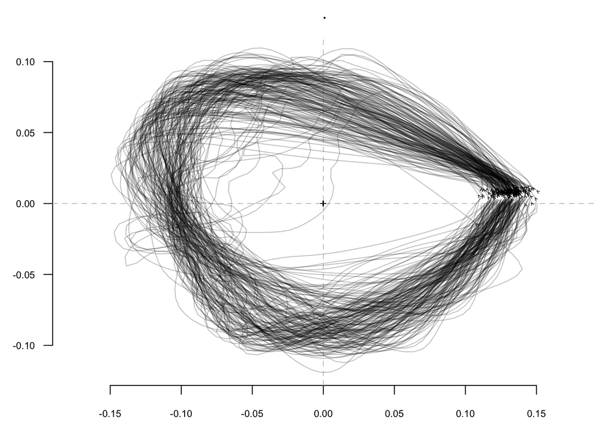

```r
#Performing Procrustes transformation, EFA, and PCA
forewing.pca <- forewings %>%
  coo_interpolate(fore.min) %>%
  coo_align()  %>%
  coo_slide(id=1) %>%
  fgProcrustes() %>%
  efourier(norm=FALSE) %>%
  PCA()

hindwing.pca <-hindwings %>%
  coo_interpolate(hind.min) %>%
  coo_align()  %>%
  coo_slide(id=1) %>%
  fgProcrustes() %>%
  efourier(norm=FALSE) %>%
  PCA()

hindwings %>%
   coo_interpolate(hind.min) %>%
   coo_align()  %>%
   coo_slide(id=1) %>%
  fgProcrustes() %>%
  stack
```

#### Comparative analysis

PC scores were first used to analyze the evolutionary rate for the hind and forewing. Species information was also added to the PCA data.

```r
out.data <- tibble(xy.file=basename(names(outs))) %>%
  mutate(identifier=gsub("XY_|_hindwing|_forewing|.txt","",xy.file)) %>%
  left_join(lep.sp)
hindwing.pca2 <-  tibble(xy.file=basename(rownames(hindwing.pca$x)),PC1=hindwing.pca$x[,1],PC2=hindwing.pca$x[,2]) %>%
  left_join(out.data)
forewing.pca2 <-  tibble(xy.file=basename(rownames(forewing.pca$x)),PC1=forewing.pca$x[,1],PC2=forewing.pca$x[,2])%>%
  left_join(out.data)
```

#### Evolutionary rates

We then examined the evolutionary rates of the PC scores across a Lepidopteran phylogentic tree from the Kawahara et al. (2019) study.

```r
drops <- lep.tree$tip.label[!lep.tree$tip.label%in%unique(out.data$species)]
lep.tree2 <- drop.tip(lep.tree,drops)

#PC1s
hind.pc1 <- hindwing.pca2 %>%
  filter(species%in% lep.tree2$tip.label) %>%
  group_by(species) %>%
  summarize(PC1=mean(PC1)) %>%
  pull

names(hind.pc1) <-  hindwing.pca2%>%
  filter(species%in% lep.tree2$tip.label) %>%
  group_by(species) %>%
  summarize(PC1=mean(PC1)) %>%
  pull(species)

fore.pc1 <- forewing.pca2 %>%
  filter(species%in% lep.tree2$tip.label) %>%
  group_by(species) %>%
  summarize(PC1=mean(PC1)) %>%
  pull(PC1)

names(fore.pc1) <-  forewing.pca2 %>%
  filter(species%in% lep.tree2$tip.label) %>%
  group_by(species) %>%
  summarize(PC1=mean(PC1)) %>%
  pull(species)

#PC2s
hind.pc2 <- hindwing.pca2 %>%
  filter(species%in% lep.tree2$tip.label) %>%
  group_by(species) %>%
  summarize(PC2=mean(PC2)) %>%
  pull(PC2)

names(hind.pc2) <-  hindwing.pca2%>%
  filter(species%in% lep.tree2$tip.label) %>%
  group_by(species) %>%
  summarize(PC2=mean(PC2)) %>%
  pull(species)

fore.pc2 <- forewing.pca2 %>%
  filter(species%in% lep.tree2$tip.label) %>%
  group_by(species) %>%
  summarize(PC2=mean(PC2)) %>%
  pull(PC2)

names(fore.pc2) <-  forewing.pca2 %>%
  filter(species%in% lep.tree2$tip.label) %>%
  group_by(species) %>%
  summarize(PC2=mean(PC2)) %>%
  pull(species)
```

#### Shifts in evolutionary rates

Phylogenetic ridge regression was used to determine whether major groups of the Lepidoptera have undergone significant changes in the rate of wing-shape evolution.

```r
library(RRphylo)
hindPC1.RR <- RRphylo(tree=lep.tree2,y=hind.pc1)
hindPC1.SS<- search.shift(RR=hindPC1.RR,status.type="clade")
```

```r
hindPC1.plot <- plotShift(RR=hindPC1.RR,SS=hindPC1.SS)

forePC1.plot <- plotShift(RR=hindPC1.RR,SS=hindPC1.SS)

# if (!require("BiocManager", quietly = TRUE))
#     install.packages("BiocManager")
#
# BiocManager::install("ggtree")

library(ggtree)
library(wesanderson)

plot_SS <- function(tre=NULL,SS=NULL,tax=NULL){

  nodes <- as.numeric(rownames(SS$single.clades))

  pal <- wes_palette("Zissou1",n=length(nodes))
  sp <- list()
  for(i in nodes){
    sp.i <- extract.clade(tre,i)$tip.label

    #print(head(tax))
    sub.names <- lapply(tax,function(x) x[x%in%sp.i])

    in.clades <- lapply(sub.names,function(x) length(x)>0)
    all.of.clade <- lapply(sub.names,function(x) all(sapply(sp.i,function(z) z%in%x)))

    high.clade <- names(sub.names)[last(which(all.of.clade==T))]
    all.clades <- names(sub.names)[which(in.clades==T)]
    crown <- ""
    if(high.clade!=last(names(sub.names))) crown <- "crown-"

    sub.clades <- NULL
    if(length(grepl("oidea",all.clades))>0) sub.clades <- all.clades[grepl("oidea",all.clades)]

    high.clade2 <- paste0(crown,high.clade,": ",paste0(sub.clades,collapse = "+"))
    sp[[paste0(i)]] <- tibble(n=i,species=sp.i,clade=high.clade2)

  }

  d <- do.call(rbind,sp)%>%
    rename(label=species)

  d2<- d %>% rename(clade_name=clade)

  p <- ggtree(tre)+ scale_y_reverse()

  p$data <- p$data %>% left_join(d) %>% left_join(tibble(node=nodes,SS$single.clades) %>% mutate(shift=ifelse(rate.difference>0,"+","-")))

  p <-  p+geom_tiplab(aes(col=clade),geom="text",size=1.2)+
    geom_cladelab(data=d2,mapping=aes(node=n,col=clade_name,label=clade_name),offset=1,size=1.5)+
    geom_hilight(data=d2,mapping = aes(node = n,fill=clade_name),alpha = 0.01)+
    scale_fill_manual(values = pal)+
    scale_color_manual(values = pal)+
    theme(legend.position = "none")+geom_nodepoint(mapping=aes(subset = shift =="-"), size=5, shape=25,fill='blue',color='blue',alpha=0.7)+
    geom_nodepoint(mapping=aes(subset = shift =="+"), size=5, shape=24, fill='red',color='red',alpha=0.7)
  p <- p+xlim(NA,6)
  res <- tibble(n=nodes,SS$single.clades) %>% left_join(d %>% select(n,clade) %>% unique)

  return(list(plot=p,res=res))

}

tax.names <- readRDS("Lep_classification.RDS")

hindPC1.res <- plot_SS(lep.tree2,hindPC1.SS,tax = tax.names)
```

#### Shape evolution correlation

Phylogenetic independent contrasts (PIC) analysis was used to determine whether hind- and forewing shape evolution is correlated.

```r
#PC1
hindPC1.pic <- pic(hind.pc1,phy = lep.tree2)
forePC1.pic <- pic(fore.pc1,phy = lep.tree2)

PC1.pic <- tibble(
  hind=hindPC1.pic,
  fore=forePC1.pic
)
```

```r
#PC2
hindPC2.pic <- pic(hind.pc2,phy = lep.tree2)
forePC2.pic <- pic(fore.pc2,phy = lep.tree2)

PC2.pic <- tibble(
  hind=hindPC2.pic,
  fore=forePC2.pic
)
```

This methods section is great!

# Results

#### Evolutionary Rates

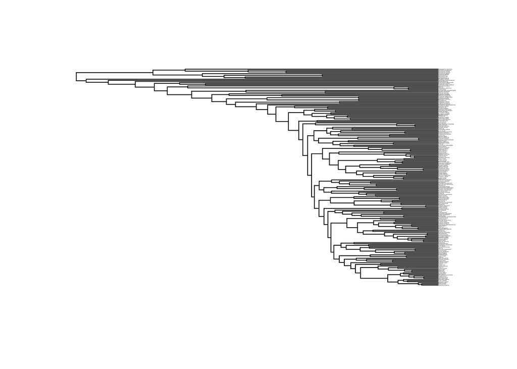

The Lepidopteran phylogenetic tree

```r
plot(lep.tree,cex=0.1)
```

```r
#Finding evolutionary rates for fore- and hindwing PCs
library(phytools)
forePC1.BM<-brownie.lite(lep.tree2,fore.pc1*10)
hindPC1.BM<-brownie.lite(lep.tree2,hind.pc1*10)

forePC2.BM<-brownie.lite(lep.tree2,fore.pc2*10)
hindPC2.BM<-brownie.lite(lep.tree2,hind.pc2*10)
```

```r
#Compare PC1 wing evolutionary rates
forePC1.BM$sig2.single
```

```
## [1] 0.006535527
```

```r
hindPC1.BM$sig2.single
```

```
## [1] 0.01014157
```

```r
#Compare PC2 wing evolutionary rates
forePC2.BM$sig2.single
```

```
## [1] 0.002411568
```

```r
hindPC2.BM$sig2.single
```

```
## [1] 0.01870921
```

Using the “noncensored test,” analysis showed that the rates of wing-shape evolution between the fore- and hindwings were different. In PC1, the difference was 0.003606043 units. In PC2, the difference was 0.016297642 units.

#### Evolutionary Rate Shifts

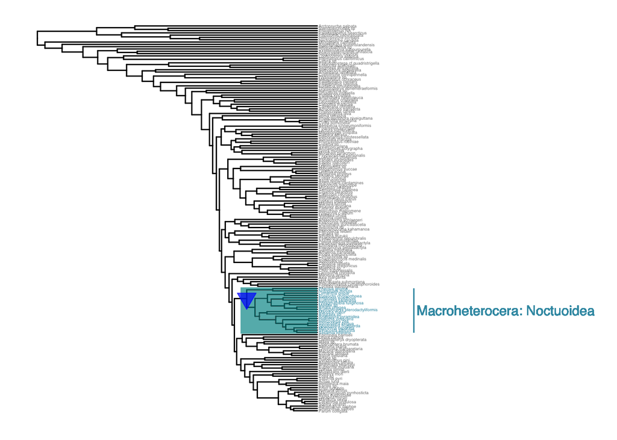

Figure 1: Lepidoptera phylogenetic tree with lineages with exceptional shifts indicated by a triangle. Blue and downward triangle signifies a low shift.

```
## # A tibble: 1 × 4
##       n rate.difference p.value clade
##   <dbl>           <dbl>   <dbl> <chr>
## 1   225        -0.00194   0.001 Macroheterocera: Noctuoidea
```

The Macroheterocera clade, specifically the Noctuoidea family underwent a significant shift in evolutionary rate, with a slowdown of -0.00194 units.

#### Correlation of wing shape evolution

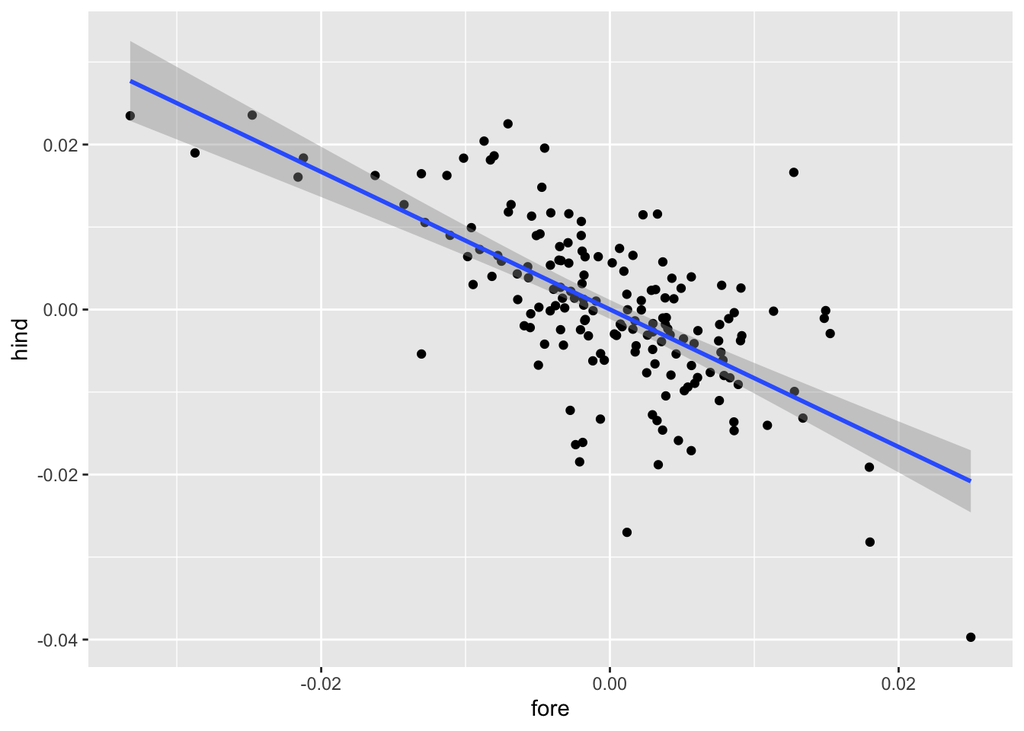

Figure 2: Linear regression of PIC-transformed PC1 values

```
##
## Call:
## lm(formula = hind ~ fore, data = PC1.pic)
##
## Residuals:
##        Min         1Q     Median         3Q        Max
## -0.0260329 -0.0040299 -0.0001764  0.0048320  0.0272273
##
## Coefficients:
##               Estimate Std. Error t value Pr(>|t|)
## (Intercept)  1.629e-05  5.845e-04   0.028    0.978
## fore        -8.335e-01  7.209e-02 -11.562   <2e-16 ***
## ---
## Signif. codes:  0 '***' 0.001 '**' 0.01 '*' 0.05 '.' 0.1 ' ' 1
##
## Residual standard error: 0.007552 on 165 degrees of freedom
## Multiple R-squared:  0.4476, Adjusted R-squared:  0.4442
## F-statistic: 133.7 on 1 and 165 DF,  p-value: < 2.2e-16
```

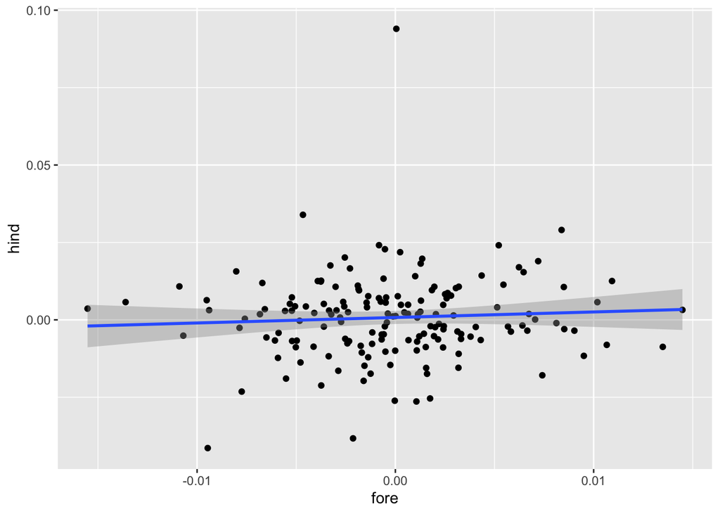

Figure 3: Linear regression of PIC-transformed PC2 values

```
##
## Call:
## lm(formula = hind ~ fore, data = PC2.pic)
##
## Residuals:
##       Min        1Q    Median        3Q       Max
## -0.040493 -0.007104  0.000357  0.006907  0.093219
##
## Coefficients:
##              Estimate Std. Error t value Pr(>|t|)
## (Intercept) 0.0007655  0.0010652   0.719    0.473
## fore        0.1778140  0.2162627   0.822    0.412
##
## Residual standard error: 0.01375 on 165 degrees of freedom
## Multiple R-squared:  0.00408,    Adjusted R-squared:  -0.001955
## F-statistic: 0.676 on 1 and 165 DF,  p-value: 0.4121
```

Analysis of fore- and hindwing PC1 shows that they are correlated. The p-value is very close to zero, indicating a significant relationship. Additionally, the R-squared value is 0.44. However, fore- and hindwing PC2s are not correlated. The p-value is 0.4121 and the R-squared value is very low.

# Discussion

The Lepidoptera play an important role in terrestrial ecosystems, and use paired wings to fly in search of places to eat, reproduce, etc. These paired wings consist of a forewing and a hindwing that consequently have their own evolutionary rates. It has been sugguested that forewing shape and size may be the result of stabilizing selection due to the physical requirements of flight, and hindwing shape is due to differential survival and reproduction of individuals due to differences in phenotype (Sourakov 2013, Barber et al. 2015, Willmott et al. 2017, Rubin et al. 2018, Chazot et al. 2016)

We need tags for thes refs to be included. This is pretty close to a cut and paste of the project description.

```r
grade <- 75
grade <- grade-3
```

# Author Contributions

All members were involved in digitizing wing shape outlines using FIJI and running code in R for analysis. Clare Mungovan: wrote the Discussions section. Adam Qu: formatted and reported data in the Results section. Matteo Torquati: wrote the Methods to the report Julie Vu: wrote the Introduction to the report.

Excellent work. Thanks for staying the course and producings a very fine analysis more relective of graduate work. Congrats to you all!

```r
print(grade)
```

```
## [1] 72
```

# References

Kawahara, Akito Y, David Plotkin, Marianne Espeland, Karen Meusemann, Emmanuel FA Toussaint, Alexander Donath, France Gimnich, et al. 2019. “Phylogenomics Reveals the Evolutionary Timing and Pattern of Butterflies and Moths.” *Proceedings of the National Academy of Sciences* 116 (45): 22657–63.

Owens, H L, D S Lewis, F L Condamine, A Y Kawahara, and R P Guralnick. 2020. “Comparative Phylogenetics of Papilio Butterfly Wing Shape and Size Demonstrates Independent Hindwing and Forewing Evolution.” *Systematic Biology* 69 (5): 813–19. https://doi.org/10.1093/sysbio/syaa029.

Patil, Sonal, and Sujata Magdum. 2017. “Insight into Wing Venation in Butterflies Belonging to Families Papilionidae, Nymphalidae and Pieridae from Dang Dist Gujarat, India.” *J. Entomol. Zool. Stud.* 5: 1596–1607.

Strauss, Richard E. 1990. “PATTERNS OF QUANTITATIVE VARIATION IN LEPIDOPTERAN WING MORPHOLOGY: THE CONVERGENT GROUPS HELICONIINAE AND ITHOMIINAE (PAPILIONOIDEA: NYMPHALIDAE).” *Evolution* 44 (1): 86–103. https://doi.org/https://doi.org/10.1111/j.1558-5646.1990.tb04281.x.